# Ridge_Lasso_Regression

### 1. House price dataset. (20 points)

The HOUSES dataset contains a collection of recent real estate listings in San Luis Obispo county and around it. The dataset is provided in RealEstate.csv. You may use \one-hot-keying" to expand the categorical variables. The dataset contains the following useful elds (You may excluding the Location and MLS in your linear regression model).

You can use any package for this question.  
• Price: the most recent listing price of the house (in dollars).  
• Bedrooms: number of bedrooms.  
• Bathrooms: number of bathrooms.  
• Size: size of the house in square feet.  
• Price/SQ.ft: price of the house per square foot.  
• Status: Short Sale, Foreclosure and Regular.

### Fitting a Ridge Regression model on the dataset

A ridge regression model was built using the features specified ('Bedrooms','Bathrooms','Size','Price/SQ.Ft',’Status’). The categorical variable Status was one-hot encoded before fitting the model. To identify the optimal regularization parameter (lambda), 5-fold cross validation was performed (for the metric “neg_mean_squared_error”). Below are the results showing the CV curve plotted against a range (60 – 180) of regularization values tried.

```
Price          float64
Bedrooms         int64
Bathrooms        int64
Size             int64
Price/SQ.Ft    float64
Status          object
dtype: object
Short Sale     516
Foreclosure    162
Regular        103
Name: Status, dtype: int64
```

```
Optimal Lambda value is :  111
Lowest CV Error is :  24111775869.33838
```

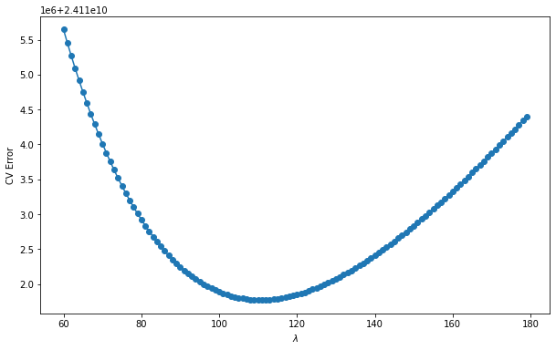

#### The optimal value of regularization parameter is 111.

```
array([ -1540.18739757,  11780.0604727 , -10239.87307512,  -7402.23003249,
         9447.12552404,    253.81601962,   1859.18718439])
```

```
16310117424146.18
```

### Lasso Regression on the dataset

For the same set of data, now a Lasso regression model was built to select the variables. A 5-fold cross validation was performed to identify the best value of regularization parameter. Below is the Cross-validation curve plotting the CV error (“neg_mean_squared_error”) against the regularization parameter. The best value for the regularization parameter was 7730.

```
Optimal Lambda value is :  7730
Lowest CV Error is :  24167992939.16026
```

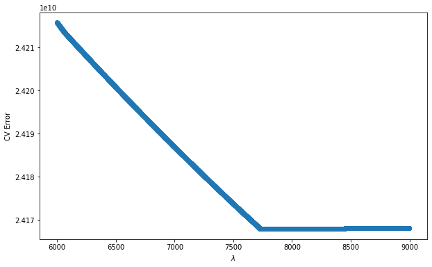

[output not shown]

```
.
```

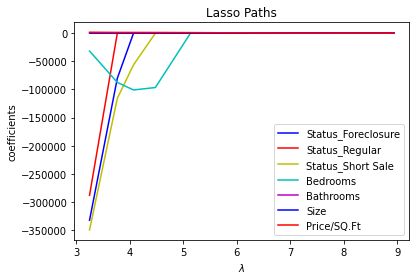

|  | Status_Foreclosure | Status_Regular | Status_Short Sale | Bedrooms | Bathrooms | Size | Price/SQ.Ft |
| --- | --- | --- | --- | --- | --- | --- | --- |
| 0 | 0.0 | 0.0 | 1.0 | 3 | 3 | 2371 | 335.30 |
| 1 | 0.0 | 0.0 | 1.0 | 4 | 3 | 2818 | 141.59 |

```
[   0.            0.            0.            0.            0.
  256.95563669 1890.21508814]
```

```
16463741177188.564
```